# Final report

John Nobles, Adam Gullion, Jonathan Aguilar

2025-05-06

**What is our Data**

Starting in 2015, Statcast, a camera-based tool which captured in-game data of Major League Baseball (MLB) players like pitching speed and strikeout percentage, was introduced to all 30 MLB stadiums. Statcast has fundamentally changed the way the game of baseball is played and changed how players are evaluated as a whole. Our team worked on this project with the goal of analyzing some of the ways Statcast has changed how teams and players approach the game.

To examine the change, our team utilized 2 datasets–one for statistics on the pitching side and one for the hitting side–from https://baseballsavant.mlb.com, the official Statcast website that contains the data related to Statcast. To evaluate and interpret the data, we used R to compare, contrast, and display the data with line graphs, box plots, violin graphs, etc.

The way we decided to approach the dataset was to investigate the impact of certain Statcast data over the years since Statcast was introduced and observe changes to different variables. To avoid large variance over the data set, we decided not to analyze player-to-player performance over the years, but instead go off the average of all qualified players (the term “qualified” meaning that the player demonstrated roughly 502 plate appearances as a hitter or 162 innings pitched as a pitcher) to observe changes. By analyzing the average data from qualified hitters and pitchers over the years, we avoid most outlier data and can evaluate how Statcast has changed players’ and teams’ strategy in the game of baseball.

**Packages Required**

We utilized the `Tidyverse` and `gridExtra` packages to analyze our data. However, one of our members couldn’t download the `Tidyverse` package correctly and, as such, downloaded the included packages in `Tidyverse` separately. Additionally, we used the `ggthemes` package to find a simplistic theme for our plots.

**Data Preparation**

We obtained both the hitting and pitching data from the statistics section of https://baseballsavant.mlb.com/. We customized it to include the variables we felt we could properly analyze over the years of 2015-2024. Both the pitching and hitting datasets contain over 1000 rows (individual players) and over 60 columns (variables of interest). As such, we can’t properly show every variable we decided to have in the dataset. The data was collected automatically by the cameras around all 30 stadiums from every MLB regular season game from 2015 to 2024.

We downloaded the data from Baseball Savant in two separate CSV files for easy use within R. As previously mentioned, due to the nature of baseball, our data is split between hitting and pitching statistics, hence each CSV file was specified for hitting or pitching. Once downloaded, we uploaded it to our main GitHub for our project so that we can utilize it while coding. Once imported to the GitHub, we assigned each CSV to its respective section of data within a coding block:

```r
hitting <- read.csv('Qualified Hitting 2015-2024stats.csv')
pitching <- read.csv('QPitchingstats.csv')
```

After proper importing, we were able to use the data within R Studio to properly analyze our data. Here’s a glimpse into the data we worked with (only displays select variables):

**Hitting dataset**

```
##   last_name..first_name k_percent exit_velocity_avg hard_hit_percent
## 1         Hunter, Torii      18.5              88.5             34.9
## 2          Ortiz, David      15.5              93.0             49.1
## 3       Rodriguez, Alex      23.4              91.3             43.9
## 4       Ramirez, Aramis      13.2              87.4             34.5
## 5        Beltré, Adrian      10.5              89.5             40.4
## 6       Beltrán, Carlos      16.0              90.6             41.9
## 7        Rollins, Jimmy      15.3              85.7             23.1
## 8        Pujols, Albert      10.9              90.7             38.3
```

**Pitching dataset**

```
##   last_name..first_name  woba xwobacon ff_avg_speed
## 1        Colon, Bartolo 0.316    0.368         90.9
## 2         Burnett, A.J. 0.315    0.375         91.7
## 3           Hudson, Tim 0.327    0.366         88.5
## 4         Buehrle, Mark 0.321    0.361         84.5
## 5          Sabathia, CC 0.343    0.345         90.8
## 6       Vogelsong, Ryan 0.337    0.393         91.6
## 7          Dickey, R.A. 0.307    0.333         82.3
## 8           Lohse, Kyle 0.362    0.407         89.8
```

**Variables of Interest**

The main variables we decided to use in the final product are `last_name..first_name`, `year`, `k_percent`, `woba`, `xwobacon`, `exit_velocity_avg`, `launch_angle_avg`, `hard_hit_percent`, `groundballs_percent`, `flyballs_percent`, `ff_avg_speed`, and `ff_avg_spin`.

- The `last_name..first_name` variable stands for the last name and first name of every player on the list. In itself, it isn’t helpful, but it is helpful in attaching a name to specific numbers in a variable.
- `k_percent` refers to the percentage a pitcher strikes out the batter they face or the percentage a hitter strikes out against a pitcher. It depends on which version of the dataset we are using on which version of `k_percent` it is.
- The stat `woba` stands for weighted on-base average. It is a version of on-base percentage that accounts for how a player reached base. It values singles over walks, doubles over singles, and so on.
- The stat `xwobacon` stands for expected weighted on-base average on contact. Think of it as the potential stat. It looks a player’s `woba` in instances where they made contact with the ball and nothing else, it doesn’t account for walks, HBP, etc. It evaluates the quality of contact by a hitter. Launch angle refers to how high or low a ball was hit in degrees. This stat helps analyze the optimization of the launch angle over the years.
- Exit Velocity (`exit_velocity_avg`) stands for the speed in MPH at which a ball is hit by a batter. A higher exit velocity generally means a higher probability of a batted ball being a hit, and as such, it is beneficial to optimize the stat.
- The stats `ff_avg_speed`, and `ff_avg_spin` refer to the speed in mph and spin in rpm of a fastball pitched. This is helpful as a pitcher would want the highest speed and spin possible on a fastball, generally.

**EDA**

Using `dplyr`, our team uncovered new information not apparent in the initial data. Through various uses of the `summarize()`, `filter()`, `mutate()`, and `group_by()` functions, we discovered trends such as the average hard hit percentage grouped by year increasing as time went on, a possible indicator of Statcast’s influence on the MLB. The code for examining these trends involved creating new variables with `mutate()`, as shown here:

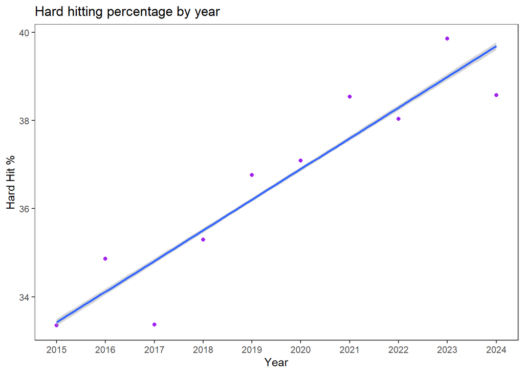

```r
pitching %>% group_by(year) %>% mutate(avg_hhp_by_year=mean(hard_hit_percent)) %>%
  ggplot(aes(year, avg_hhp_by_year)) +
  geom_point(color='purple') +
  geom_smooth(formula='y ~ x', method='lm') +
  theme_test() +
  labs(title='Hard hitting percentage by year',
       x='Year',
       y='Hard Hit %',
       color='Average HH% per year',
       legend='a') +
  scale_x_continuous(breaks=c(2015:2024))
```

Another example of our use of these functions is how we examined the average launch angle over time. As you might expect, hitting the ball at a higher angle would yield better results (i.e. more home runs). So, grouping by year and creating a new variable for the average launch angle by year using the `summarize()` and `group_by()` functions allowed us to discover how average launch angle has had a general upward trend since Statcast was first implemented in 2015 (shown below).

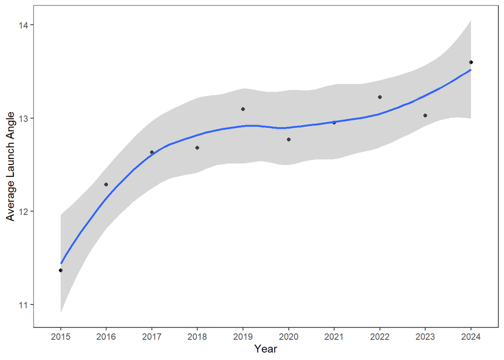

```r
hitting %>%
  filter(year >= 2015, year <= 2024) %>%
  group_by(year) %>%
  summarize(avg_launch_angle = mean(launch_angle_avg)) %>%
  ggplot(aes(x = factor(year), y = avg_launch_angle)) +
  geom_point() +
  theme_test() +
  geom_smooth(aes(group = 1), method = "loess") +
  xlab("Year") +
  ylab("Average Launch Angle")
```

The story that the previous 2 plots tell (as well as many other plots we created which appear on our presentation) is the story of Statcast’s clear effect on player performance in the MLB. Since 2015, it is clear to us that player performance has generally improved on both the hitting and pitching sides of things, and Statcast is a leading contender for why this is happening. Statcast offers a multitude of points of analysis which the professional teams of the MLB would be remiss to avoid examining.

**A Fascinating Table**

One intriguing and humorous table we created shows the players with the lowest average launch angle. This statistic measures how far above or below the bat the initial direction of the ball post-hit is. So, if the ball somehow goes straight up after batting, the launch angle is 90 degrees. If the ball goes directly forward and parallel to the ground, the launch angle is 0 degrees. We’ve displayed 12 players with the lowest launch angle averages in our dataset. You’re eyes do not deceive you; Raimel Tapia had an average launch angle of -4.4 degrees in 2021, meaning that, on **average,** he hit the ball into the ground instead of into the air. It is also no surprise that 11 of the bottom 12 of this category have a below average (most *far* below average) number home runs.

```
##    last_name..first_name launch_angle_avg year home_run
## 1          Tapia, Raimel             -4.4 2021        6
## 2           Hosmer, Eric             -1.5 2018       18
## 3          Ramos, Wilson             -0.1 2019       14
## 4      Yelich, Christian              0.0 2015        7
## 5           Desmond, Ian              0.1 2018       22
## 6    Kiner-Falefa, Isiah              0.8 2020        3
## 7           Lopez, Nicky              1.4 2020        1
## 8       Villar, Jonathan              1.6 2020        2
## 9    Kendrick III, Howie              1.7 2016        8
## 10         Tapia, Raimel              1.8 2020        1
## 11        Escobar, Yunel              1.9 2016        5
## 12         Anderson, Tim              2.0 2023        1
```

For reference, here is the league average number of home runs per season from 2015-2024:

```
##   League_Average_Home_Runs
## 1                 20.49964
```

**Strikeout Percentage**

Another revealing trend that related to Statcast is strikeout percentage over time. Before discussing this, we would like to introduce Spider Tack. Spider Tack is a sticky substance that was used along with sweat, suncscreen, and other substances by pitchers in the MLB to increase spin rate in their pitches. The MLB initiated a crackdown on Spider Tack in July of 2021 (mid-season). The graph of strikeout percentage offers a fascinating insight into the effects of both Statcast as well as the ban of Spider Tack.

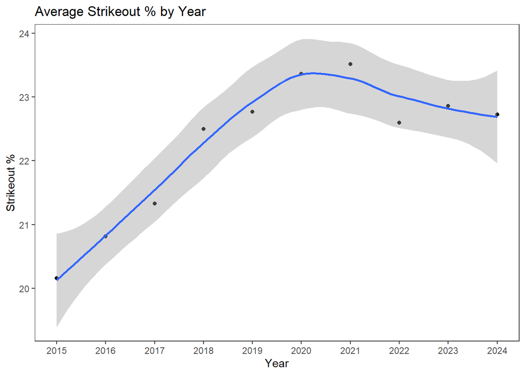

Since Statcast was implemented in 2015, strikeout percentage saw significant initial increases. However, we believe Statcast was not the only cause of these gains. While Statcast was a tool used in the MLB during the period from 2015 to 2021, so was Spider Tack. We postulate that the combination of increased data analysis using Statcast and increased cheating attempts using substances like Spider Tack gave MLB pitchers drastic in-game advantages, hence they struck out more and more as time went on and they continued utilizing these advantages. We also believe that strikeout percentage took a turn after 2021 because of the crackdown on Spider Tack. But again, Spider Tack is not the only tool at play; if it were, we might expect to see strikeout percentage return back to around 20% (where it was in 2015). However, Statcast is playing a significant role too. We believe Statcast has mitigated the effects of banning Spider Tack such that pitchers are still somewhat maintaining their pre-ban strikeout rates.

**Summary**

In short the main goal for our team was to analyze the effects Statcast had on player performance. More specifically, how did player performance evolve over time as a result of MLB teams increasingly using Statcast in their training programs.

All of these findings help us establish that there was indeed an impact of Statcast on player performance in the years since it was implemented. Limitations of these findings include the lack of back-tracking data as this data was only included in the middle of 2023. Furthermore, this data only followed qualified hitters in MLB and not in MiLB, NPB, KBO, or any other baseball leagues.